# Practical Machine Learning Course Project

Making Prediction Using Different Machine Leanring Algorithms

Chi Zhang

11/18/2019

## Introduction

Wearable devices such as Apple Watch, Jawbone Up, Nike FuelBand, and Fitbit have enabled us to monitor and record our daily excercises and trainings. These devices collect a large amount of personal activity data to help people take measurements about themselves, understand their behavior, and improve their performance and physical health. The previous analysis on this type of data focused on quantify how to distinguish between different activities and how much of each acitivity people do. There is a lack in vaild models and algorithms to quantify how well people perform these activities. The target of this project is to build a model that can use data collected by those wearbale devices to predict and forcase the manner in which people do these activities.

## Data source and information

The data used for this project come from the website: http://web.archive.org/web/20161224072740/http:/groupware.les.inf.puc-rio.br/har. The data contains training data for model development and 20 test data points for verifying the model’s accuracy.

Six participants were asked to perform barbell lifts corretly and incorrelty in 5 different ways, which is the “classe” variable in the training data set. The accelerometers were placed on participants’ belt, forearm, arm, and dumbell to collect movement data.

## Loading the data

```r
#set directory
setwd("~/Documents/R Directory/Practical Machine Learning Project")

#load useful packages
library(caret)
library(corrplot)
library(rattle)
library(rpart)

#load data from the website
train_data <- read.csv(url("https://d396qusza40orc.cloudfront.net/predmachlearn/pml-training.csv"), header = TRUE)
test_data <- read.csv(url("https://d396qusza40orc.cloudfront.net/predmachlearn/pml-testing.csv"), header = TRUE)
```

## Exploring the data

```r
#explore the data
dim(train_data)
```

```
## [1] 19622   160
```

```r
str(train_data)
```

```
## 'data.frame':    19622 obs. of  160 variables:
##  $ X                       : int  1 2 3 4 5 6 7 8 9 10 ...
##  $ user_name               : Factor w/ 6 levels "adelmo","carlitos",..: 2 2 2 2 2 2 2 2 2 2 ...
##  $ raw_timestamp_part_1    : int  1323084231 1323084231 1323084231 1323084232 1323084232 1323084232 1323084232 1323084232 1323084232 1323084232 ...
##  $ raw_timestamp_part_2    : int  788290 808298 820366 120339 196328 304277 368296 440390 484323 484434 ...
##  $ cvtd_timestamp          : Factor w/ 20 levels "02/12/2011 13:32",..: 9 9 9 9 9 9 9 9 9 9 ...
##  $ new_window              : Factor w/ 2 levels "no","yes": 1 1 1 1 1 1 1 1 1 1 ...
##  $ num_window              : int  11 11 11 12 12 12 12 12 12 12 ...
##  $ roll_belt               : num  1.41 1.41 1.42 1.48 1.48 1.45 1.42 1.42 1.43 1.45 ...
##  $ pitch_belt              : num  8.07 8.07 8.07 8.05 8.07 8.06 8.09 8.13 8.16 8.17 ...
##  $ yaw_belt                : num  -94.4 -94.4 -94.4 -94.4 -94.4 -94.4 -94.4 -94.4 -94.4 -94.4 ...
##  $ total_accel_belt        : int  3 3 3 3 3 3 3 3 3 3 ...
##  $ kurtosis_roll_belt      : Factor w/ 397 levels "","-0.016850",..: 1 1 1 1 1 1 1 1 1 1 ...
##  $ kurtosis_picth_belt     : Factor w/ 317 levels "","-0.021887",..: 1 1 1 1 1 1 1 1 1 1 ...
##  $ kurtosis_yaw_belt       : Factor w/ 2 levels "","#DIV/0!": 1 1 1 1 1 1 1 1 1 1 ...
```

[output cut: 86 more lines]

```r
dim(test_data)
```

```
## [1]  20 160
```

```r
str(test_data)
```

```
## 'data.frame':    20 obs. of  160 variables:
##  $ X                       : int  1 2 3 4 5 6 7 8 9 10 ...
##  $ user_name               : Factor w/ 6 levels "adelmo","carlitos",..: 6 5 5 1 4 5 5 5 2 3 ...
##  $ raw_timestamp_part_1    : int  1323095002 1322673067 1322673075 1322832789 1322489635 1322673149 1322673128 1322673076 1323084240 1322837822 ...
##  $ raw_timestamp_part_2    : int  868349 778725 342967 560311 814776 510661 766645 54671 916313 384285 ...
##  $ cvtd_timestamp          : Factor w/ 11 levels "02/12/2011 13:33",..: 5 10 10 1 6 11 11 10 3 2 ...
##  $ new_window              : Factor w/ 1 level "no": 1 1 1 1 1 1 1 1 1 1 ...
##  $ num_window              : int  74 431 439 194 235 504 485 440 323 664 ...
##  $ roll_belt               : num  123 1.02 0.87 125 1.35 -5.92 1.2 0.43 0.93 114 ...
##  $ pitch_belt              : num  27 4.87 1.82 -41.6 3.33 1.59 4.44 4.15 6.72 22.4 ...
##  $ yaw_belt                : num  -4.75 -88.9 -88.5 162 -88.6 -87.7 -87.3 -88.5 -93.7 -13.1 ...
##  $ total_accel_belt        : int  20 4 5 17 3 4 4 4 4 18 ...
##  $ kurtosis_roll_belt      : logi  NA NA NA NA NA NA ...
##  $ kurtosis_picth_belt     : logi  NA NA NA NA NA NA ...
##  $ kurtosis_yaw_belt       : logi  NA NA NA NA NA NA ...
```

[output cut: 86 more lines]

The analysis above shows two important aspects: (1) the first seven columns contain information on data identifiers that should not be included in the model; (2) both training and test datasets contain large number of columns with NA and empty values. So a cleaning step is needed to prepare the data for further processing.

## Cleaning the data

```r
#clean the input training and test data to remove first seven columns
train_data <- train_data[, -c(1:7)]
test_data <- test_data[, -c(1:7)]

#further clean the training and test data to remove columns with more than 90% NA or empty values
columns_most_nas_train <- which(colSums(is.na(train_data) | train_data == "") > 0.9*dim(train_data)[1])
if (length(columns_most_nas_train) != 0) {
  train_data <- train_data[, -columns_most_nas_train]
}
columns_most_nas_test <- which(colSums(is.na(test_data) | test_data == "") > 0.9*dim(test_data)[1])
if (length(columns_most_nas_test) != 0) {
  test_data <- test_data[, -columns_most_nas_test]
}
dim(train_data)
```

```
## [1] 19622    53
```

```r
dim(test_data)
```

```
## [1] 20 53
```

## Creating training and test sets from the training data

In order to apply different machine learning algorithms, the training data needs to be partitioned into two parts, a training part, which contains 70% of the training data, and a testing part, which contains the rest 30% data.

```r
#creat partitions from the training data, 70% for modeling and 30% for cross validation
train_partition <- createDataPartition(train_data$classe, p = 0.7, list = FALSE)
train_set <- train_data[train_partition, ]
test_set <- train_data[-train_partition, ]
dim(train_set)
```

```
## [1] 13737    53
```

```r
dim(test_set)
```

```
## [1] 5885   53
```

## Checking correlations between variables

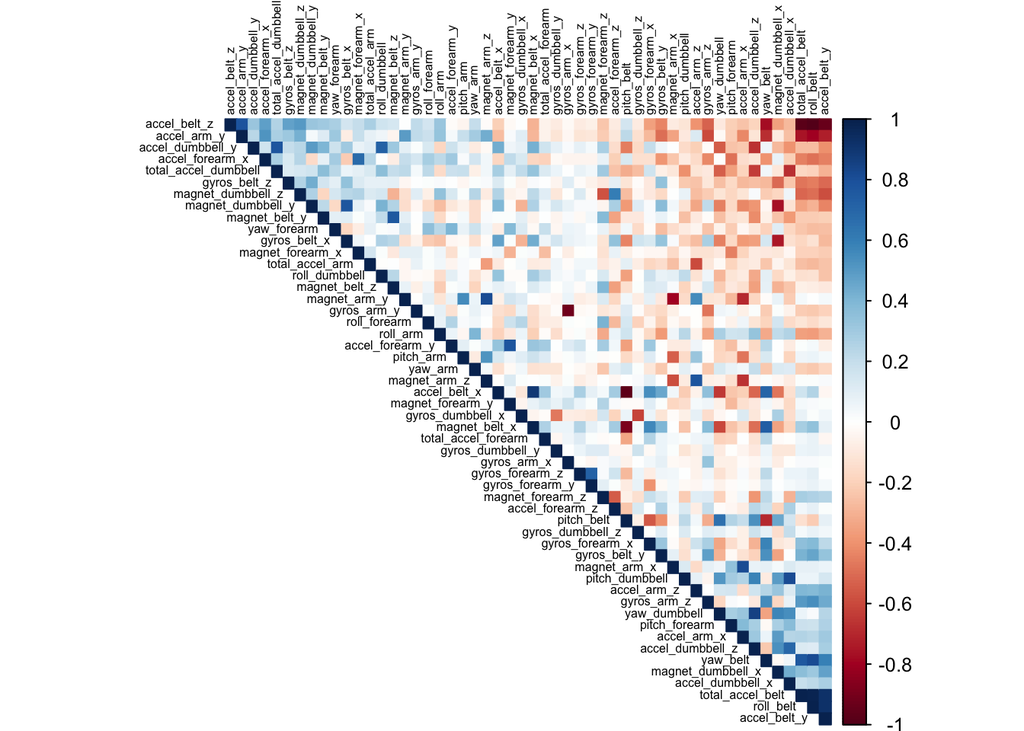

```r
#check the correlations between variables
correlation_matrix <- cor(train_set[, -53])
corrplot(correlation_matrix, method = "color", type = "upper", order = "FPC",
         tl.cex = 0.5, tl.col = rgb(0,0,0))
```

The darker the color on the graph, the stronger the correlation between the two variables is.

## Machine learning model selection and evaluation

In this part of the report, three different machine learning algorithms, which are Decision Trees, Random Forest, and Stochastic Gradient Boosting Machine (GBM), are tested on the training data. A confusion matrix is generated for each model. The result will show the accuracy of each model on the test set.

## Model 1: Decision Trees

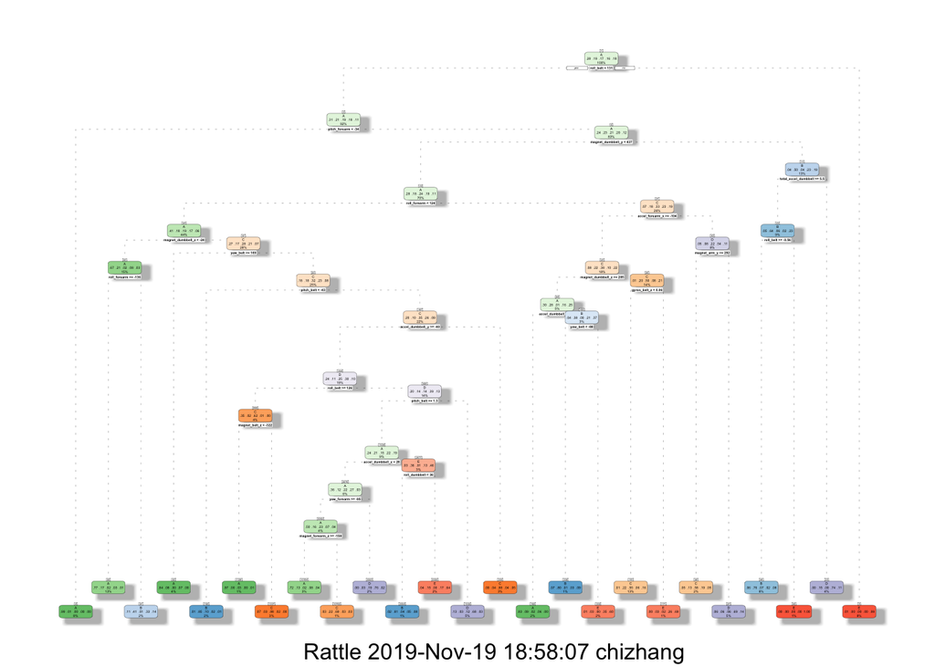

```r
#the first algorithm is Decision Trees
traindata_decision_trees <- rpart(classe ~ ., data = train_set, method = "class")
fancyRpartPlot(traindata_decision_trees)
```

```r
testdata_decision_trees <- predict(traindata_decision_trees, newdata = test_set, type = "class")
confusion_matrix_decision_trees <- confusionMatrix(testdata_decision_trees, test_set$classe)
confusion_matrix_decision_trees
```

```
## Confusion Matrix and Statistics
##
##           Reference
## Prediction    A    B    C    D    E
##          A 1494  175   35   53   12
##          B   57  647   53   79   92
##          C   44  226  867   98  135
##          D   62   67   70  649   72
##          E   17   24    1   85  771
##
## Overall Statistics
##
##                Accuracy : 0.7524
##                  95% CI : (0.7412, 0.7634)
##     No Information Rate : 0.2845
##     P-Value [Acc > NIR] : < 2.2e-16
##
##                   Kappa : 0.6865
##
##  Mcnemar's Test P-Value : < 2.2e-16
##
## Statistics by Class:
##
##                      Class: A Class: B Class: C Class: D Class: E
## Sensitivity            0.8925   0.5680   0.8450   0.6732   0.7126
## Specificity            0.9347   0.9408   0.8965   0.9449   0.9736
## Pos Pred Value         0.8445   0.6972   0.6328   0.7054   0.8586
## Neg Pred Value         0.9563   0.9007   0.9648   0.9366   0.9376
## Prevalence             0.2845   0.1935   0.1743   0.1638   0.1839
## Detection Rate         0.2539   0.1099   0.1473   0.1103   0.1310
## Detection Prevalence   0.3006   0.1577   0.2328   0.1563   0.1526
## Balanced Accuracy      0.9136   0.7544   0.8708   0.8091   0.8431
```

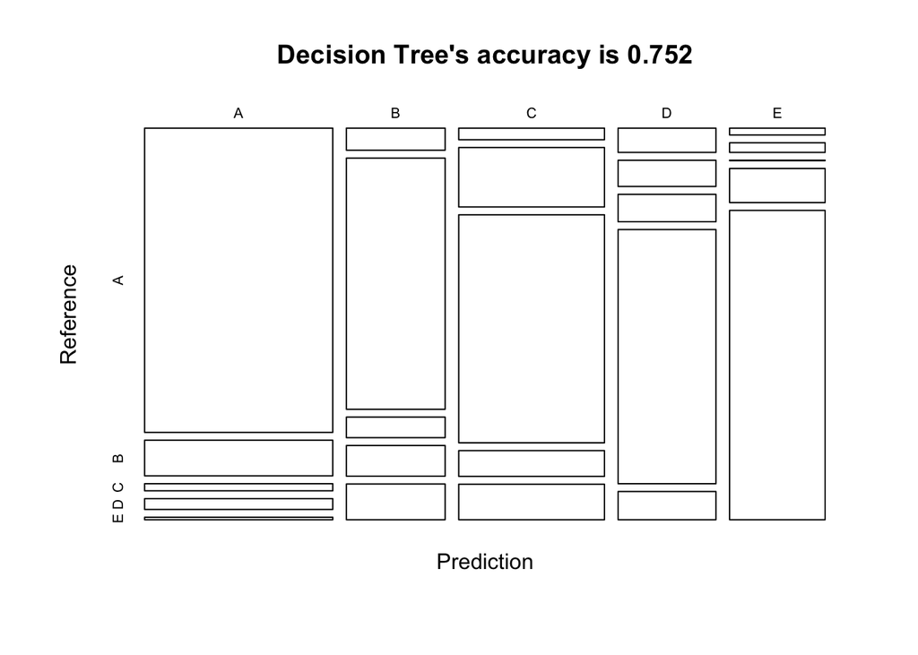

```r
#plot the results from the matrix to show the accuracy of the Decision Trees algorithm
plot(confusion_matrix_decision_trees$table,
     col = confusion_matrix_decision_trees$byClass,
     main = paste("Decision Tree's accuracy is",
                  round(confusion_matrix_decision_trees$overall['Accuracy'], 3)))
```

```r
round(confusion_matrix_decision_trees$overall['Accuracy'], 3)
```

```
## Accuracy
##    0.752
```

## Model 2. Random Forest

```r
#the second algorithm is Random Forest
random_forest_control <- trainControl(method = "cv", number = 5, verboseIter = FALSE)
traindata_random_forest <- train(classe ~ ., data = train_set,
                                 method = "rf", trControl = random_forest_control)
traindata_random_forest$finalModel
```

```
##
## Call:
##  randomForest(x = x, y = y, mtry = param$mtry)
##                Type of random forest: classification
##                      Number of trees: 500
## No. of variables tried at each split: 27
##
##         OOB estimate of  error rate: 0.73%
## Confusion matrix:
##      A    B    C    D    E class.error
## A 3901    4    1    0    0 0.001280082
## B   21 2631    5    1    0 0.010158014
## C    0   14 2371   11    0 0.010434057
## D    0    1   24 2225    2 0.011989343
## E    0    3    3   10 2509 0.006336634
```

```r
testdata_random_forest <- predict(traindata_random_forest, newdata = test_set)
confusion_matrix_random_forest <- confusionMatrix(testdata_random_forest, test_set$classe)
confusion_matrix_random_forest
```

```
## Confusion Matrix and Statistics
##
##           Reference
## Prediction    A    B    C    D    E
##          A 1671    8    0    0    0
##          B    1 1130    6    0    0
##          C    1    1 1016   12    3
##          D    0    0    4  951    8
##          E    1    0    0    1 1071
##
## Overall Statistics
##
##                Accuracy : 0.9922
##                  95% CI : (0.9896, 0.9943)
##     No Information Rate : 0.2845
##     P-Value [Acc > NIR] : < 2.2e-16
##
##                   Kappa : 0.9901
##
##  Mcnemar's Test P-Value : NA
##
## Statistics by Class:
##
##                      Class: A Class: B Class: C Class: D Class: E
## Sensitivity            0.9982   0.9921   0.9903   0.9865   0.9898
## Specificity            0.9981   0.9985   0.9965   0.9976   0.9996
## Pos Pred Value         0.9952   0.9938   0.9835   0.9875   0.9981
## Neg Pred Value         0.9993   0.9981   0.9979   0.9974   0.9977
## Prevalence             0.2845   0.1935   0.1743   0.1638   0.1839
## Detection Rate         0.2839   0.1920   0.1726   0.1616   0.1820
## Detection Prevalence   0.2853   0.1932   0.1755   0.1636   0.1823
## Balanced Accuracy      0.9982   0.9953   0.9934   0.9920   0.9947
```

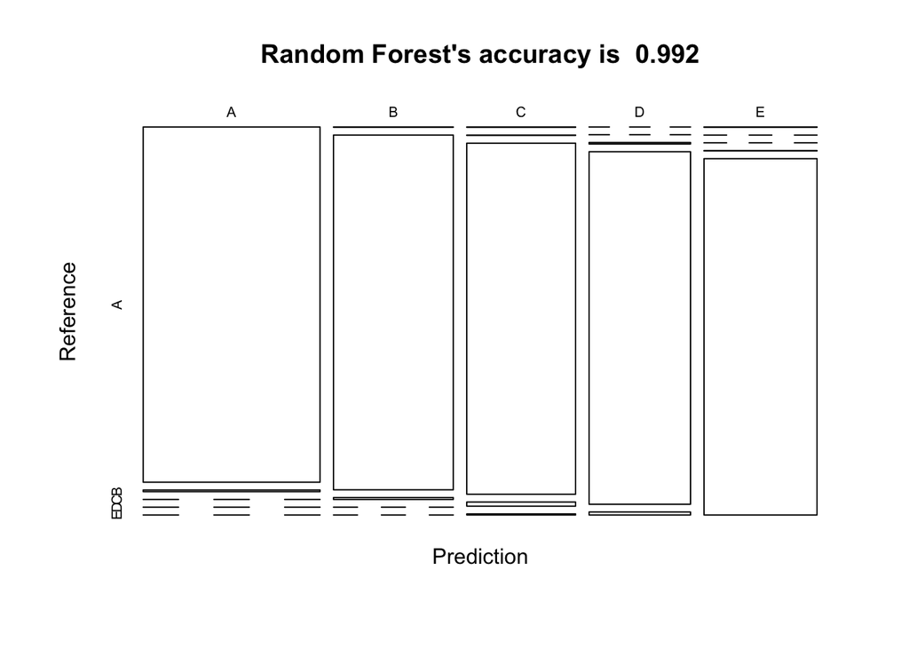

```r
#plot the results from the matrix to show the accuracy of the Random Forest algorithm
plot(confusion_matrix_random_forest$table,
     col = confusion_matrix_random_forest$byClass,
     main = paste("Random Forest's accuracy is ",
                  round(confusion_matrix_random_forest$overall['Accuracy'], 3)))
```

```r
round(confusion_matrix_random_forest$overall['Accuracy'], 3)
```

```
## Accuracy
##    0.992
```

## Model 3. GBM

```r
#the third algorithm is Stochastic Gradient Boosting Machine (GBM)
GBM_control <- trainControl(method = "repeatedcv", number = 5, repeats = 1)
traindata_GBM <- train(classe ~ ., data = train_set, method = "gbm",
                       trControl = GBM_control, verbose = FALSE)
traindata_GBM$finalModel
```

```
## A gradient boosted model with multinomial loss function.
## 150 iterations were performed.
## There were 52 predictors of which 52 had non-zero influence.
```

```r
testdata_GBM <- predict(traindata_GBM, newdata = test_set)
confusion_matrix_GBM <- confusionMatrix(testdata_GBM, test_set$classe)
confusion_matrix_GBM
```

```
## Confusion Matrix and Statistics
##
##           Reference
## Prediction    A    B    C    D    E
##          A 1653   31    0    2    2
##          B   12 1075   21    7   15
##          C    5   31  997   40    8
##          D    2    1    6  911   22
##          E    2    1    2    4 1035
##
## Overall Statistics
##
##                Accuracy : 0.9636
##                  95% CI : (0.9585, 0.9683)
##     No Information Rate : 0.2845
##     P-Value [Acc > NIR] : < 2.2e-16
##
##                   Kappa : 0.954
##
##  Mcnemar's Test P-Value : 1.036e-11
##
## Statistics by Class:
##
##                      Class: A Class: B Class: C Class: D Class: E
## Sensitivity            0.9875   0.9438   0.9717   0.9450   0.9566
## Specificity            0.9917   0.9884   0.9827   0.9937   0.9981
## Pos Pred Value         0.9793   0.9513   0.9223   0.9671   0.9914
## Neg Pred Value         0.9950   0.9865   0.9940   0.9893   0.9903
## Prevalence             0.2845   0.1935   0.1743   0.1638   0.1839
## Detection Rate         0.2809   0.1827   0.1694   0.1548   0.1759
## Detection Prevalence   0.2868   0.1920   0.1837   0.1601   0.1774
## Balanced Accuracy      0.9896   0.9661   0.9772   0.9694   0.9773
```

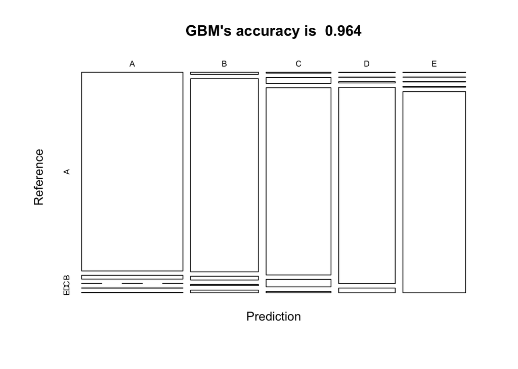

```r
#plot the results from the matrix to show the accuracy of the GBM algorithm
plot(confusion_matrix_GBM$table,
     col = confusion_matrix_GBM$byClass,
     main = paste("GBM's accuracy is ",
                  round(confusion_matrix_GBM$overall['Accuracy'], 3)))
```

```r
round(confusion_matrix_GBM$overall['Accuracy'], 3)
```

```
## Accuracy
##    0.964
```

Comparing all three models’ accuracy values, it can be concluded that the Random Forest model is the most accurate model and will be applied to the test data to predict the “classe” results.

## Applying the Random Forest model to the test data

```r
#the Random Forest has the highest accuracy, so apply the algorithm to the test data
testdata_result <- predict(traindata_random_forest, newdata = test_data)
testdata_result
```

```
##  [1] B A B A A E D B A A B C B A E E A B B B
## Levels: A B C D E
```